# Enjeux du logiciel libre

## Définitions

Comparaison des droits selon le type de logiciel.

| Type de logiciel | Lire le code | Modifier | Redistribuer | Usage commercial |
| --- | --- | --- | --- | --- |
| Logiciel libre | Oui | Oui | Oui | Oui |
| Open source | Oui | Oui | Oui | Oui |
| « Ouvert » | Oui | Partiellement | Partiellement | Non |
| Propriétaire | Non | Non | Non | Payant |

*“Libre et open source, c’est pareil ?”* → **Presque**

## Libre vs open source

### Logiciel libre

- **1983** : Richard Stallman, projet GNU
- Une question **éthique**
- 4 libertés : exécuter, étudier, modifier, partager
- Licences **copyleft** (GPL) : si tu redistribues, tu partages

> *“Free as in free speech, not as in free beer”*

### Open source

- **1998** : Open Source Initiative (OSI)
- Une question **pragmatique**
- Un terme pensé pour convaincre les entreprises
- Licences **permissives** (MIT, Apache) : fais ce que tu veux

> *“Given enough eyeballs, all bugs are shallow”* - Eric S. Raymond

En pratique : **les mêmes logiciels**, pas les mêmes arguments.

## “Ouvert” : la zone grise

On voit le code… mais on ne peut pas en faire un concurrent.

Exemples de changements de licence et de leurs conséquences.

| Projet | Licence avant | Licence après | Réponse | Retour ? |
| --- | --- | --- | --- | --- |
| MongoDB (2018) | AGPL | SSPL | Clone AWS DocumentDB | Non |
| Elasticsearch (2021) | Apache 2.0 | SSPL / Elastic License | Fork OpenSearch | AGPL (2024) |
| Terraform (2023) | MPL | BSL | Fork OpenTofu | Non (racheté par IBM) |
| Redis (2024) | BSD | RSAL / SSPL | Fork Valkey | AGPL (2025) |

## Qui utilise l’open source ?

96%

des logiciels commerciaux contiennent de l’open source

100%

des 500 plus gros supercalculateurs tournent sous Linux

~70%

des smartphones dans le monde (Android)

8 800 Md$

pour tout réécrire si l’open source n’existait pas

- Tous les langages de programmation et leurs packages
- Toutes les technologies autour de l’IA
- VLC, Firefox, Blender, LibreOffice…

## Qui utilise l’open source ?

96% de la valeur

est produite par **5% des développeurs**

Hoffmann, Nagle & Zhou, *The Value of Open Source Software*, Harvard Business School (2024)

## Qui décide ?

### Big tech

- **Google**: Android, Chromium, TensorFlow…
- **Microsoft**: TypeScript, VS Code, …
- **Meta**: PyTorch, React, …

Rachats récents:

- **OpenAI**: Astral
- **Anthropic**: Bun
- **IBM**: Red Hat
- **Cloudflare**: VoidZero

### Et les autres

[figure not shown]

## xz utils

- Environ ~100 millions d’ordinateurs qui l’utilisent
- Un seul mainteneur, **Lasse Colin**
- En 2022: *“I haven’t lost interest but my ability to care has been fairly limited mostly due to **longterm mental health issues** but also due to some other things. Recently I’ve worked off-list a bit with Jia Tan on XZ Utils and perhaps he will have a **bigger role in the future**, we’ll see.”*
- Collaboration pendant ~2 ans
- CVSS 10

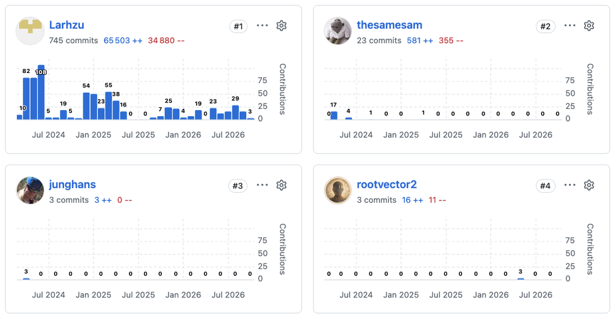

- Recommandation : *“L’attaque informatique la plus sophistiquée de l’Histoire, Micode”*

## IA et modèles ouverts

Un modèle d’IA, c’est :

- des **données** d’entraînement
- du **code** d’entraînement
- des millions de $ de calcul
- des **poids** (le fichier final)

### Logiciel

Code source → compilation → **binaire**

### IA

Données + code → entraînement → **poids**

→ Publier les poids sans le reste, c’est publier **un binaire sans le code source**.

## Open source ou “open weights” ?

Comparaison de l’ouverture des poids, du code et des données de plusieurs modèles.

| Modèle | Poids ouverts | Code ouvert | Données ouvertes | Licence |
| --- | --- | --- | --- | --- |
| GPT-5, Claude, Gemini | Non | Non | Non | Propriétaire (API) |
| Llama (Meta) | Oui | Partiellement | Non | Llama License (max 700M utilisateurs) |
| DeepSeek R1 | Oui | Partiellement | Non | MIT |
| Qwen, Mistral, gpt-oss | Oui | Partiellement | Non | Apache 2.0 (en général) |
| OLMo (Ai2) | Oui | Oui | Oui | Apache 2.0 |

La quasi-totalité des modèles dits “open source” sont en fait **open weights**.

*Selon la définition de l’OSI (2024), Llama n’est pas open source.*

## Pourquoi c’est important ?

- **Confidentialité** : faire tourner un modèle en local sans envoyer ses données
- **Souveraineté** : ne pas dépendre de 3 entreprises américaines
- **Recherche** : on ne peut pas étudier ce qu’on ne peut pas ouvrir
- **Reproductibilité** : modèle inutilisable au bout de quelques années
- **Prix** : la concurrence des modèles ouverts fait baisser les prix
- **Janvier 2025** : DeepSeek publie R1 en MIT
  - Nvidia perd **~600 milliards $** en bourse en une journée
- **Octobre 2026** : OpenAI supprime GPT 3.5 de ses services

## Science et logiciel libre

La science moderne tourne sur du logiciel libre :

### 2016

Ondes gravitationnelles (LIGO)

*NumPy, SciPy, Matplotlib*

### 2019

Première image d’un trou noir

*NumPy, Matplotlib, Astropy*

### 2024

Prix Nobel de chimie (AlphaFold)

*Code publié sous Apache 2.0*

Et dans les labos : R, Python, Jupyter, Quarto/R Markdown, LaTeX…

## Quand la science dépend d’un logiciel fermé

Excel transforme automatiquement certains noms de gènes en dates :

`SEPT1` → 1-Sep `MARCH1` → 1-Mar

- **~20%** des articles de génomique avec des fichiers Excel sont touchés (Ziemann et al., 2016)
- On ne peut pas corriger Excel : ce n’est pas notre code
- **2020** : la communauté scientifique **renomme 27 gènes** (`SEPT1` → `SEPTIN1`)
- **2023** : Microsoft ajoute enfin une option pour désactiver la conversion

Avec un logiciel propriétaire, c’est **la science qui s’adapte au logiciel**.

## Reproductibilité

Un résultat scientifique = **données** + **code** + **environnement**

### Logiciel propriétaire

- SAS, SPSS, Stata, MATLAB…
- Reproductible… **si on paie la licence**
- Et si la version existe encore

### Logiciel libre

- R, Python, Julia…
- Reproductible par **n’importe qui**
- Code archivé pour toujours (Software Heritage, Inria)
- Plan national pour la science ouverte (2021 - 2024)
- Stratégie de science ouverte (2026 – 2033)